# Tidytext

Jasmine Dogu, Brian Wimmer, Lindsey Norberg

10/15/2020

## Reading in the Text and Cleaning the Data

Before beginning our sentiment analysis, we begin by reading in the text file and then performing some minimal data cleaning. We begin by reading in the raw text file; however, we then need to prepare it to be in a usable form. To do this, we unnest the text, meaning that we will separate the text into individual words. Then, we want to remove irrelevant or uninformative words like “a” or “the,” also known as stop words. We then take a count of the frequency that we see each of the unnested words appear across all 100 publications. We now have usable data that is ready for sentiment analysis.

### USA Today ggplot of Frequency of Words

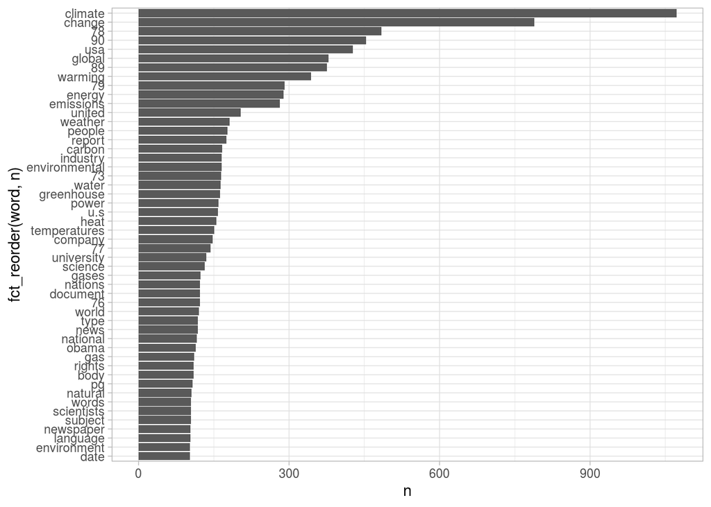

We can see in the plot for USA Today that both “climate” and “change” were the most used words, registering more than 1050 and 750 words, respectively. Following them were the numbers “78” and “90”. We can infer that these could have been talking about temperatures or certain thresholds of global warming.

### NYT ggplot of Frequency of Words

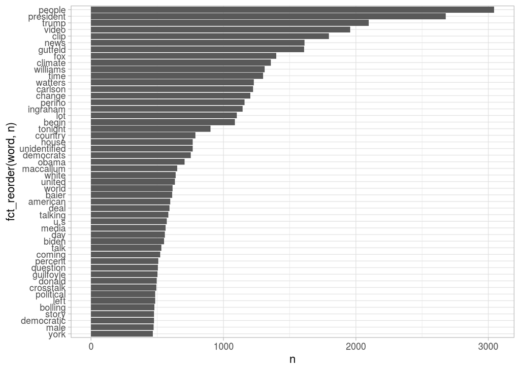

We can see in the plot for the New York Times that “people”, “president”, and “trump” were the most used words. “People” was registered more than 3000 times, while “president” and “trump” were registered more than 2500 and 2000 times, respectively. As the words “president” and “trump” were both used a huge amount of times, we could infer that these two words could have been used together often in articles. The words indicated in the plot also seem to be more political than in the USA Today articles, as many of them are names of politicians.

### Fox News ggplot of Frequency of Words

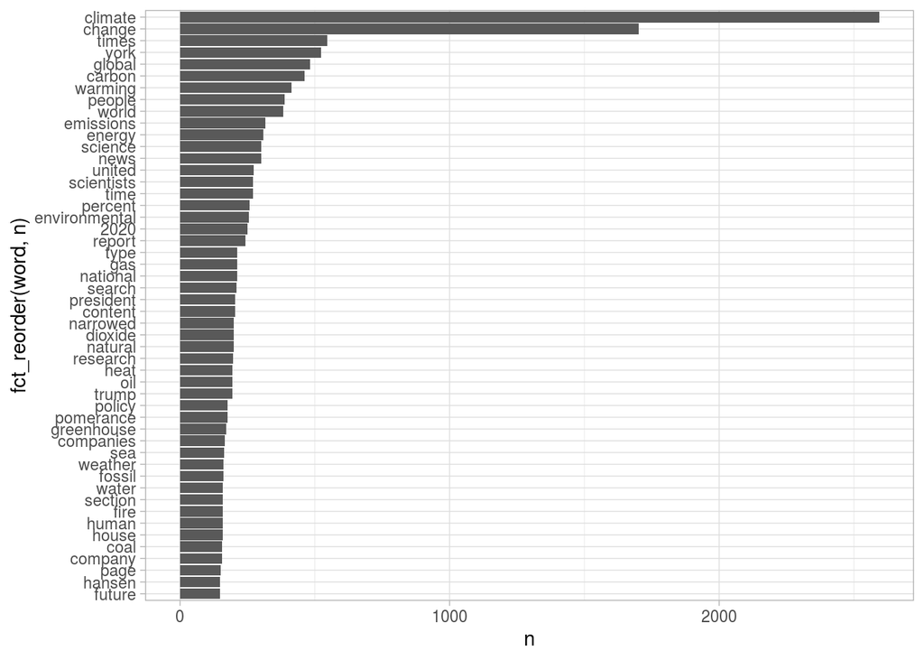

We can see in the plot for Fox News that “climate” and “change” were the most frequent words, with over 2500 words and over 1500 words, respectively. We can infer, again, that these words are typically used together, which is why they are similar in word counts. Following those words, “times”, “york”, “global”, “carbon”, and “warming” also saw high frequency.

### The Australian ggplot of Frequency of Words

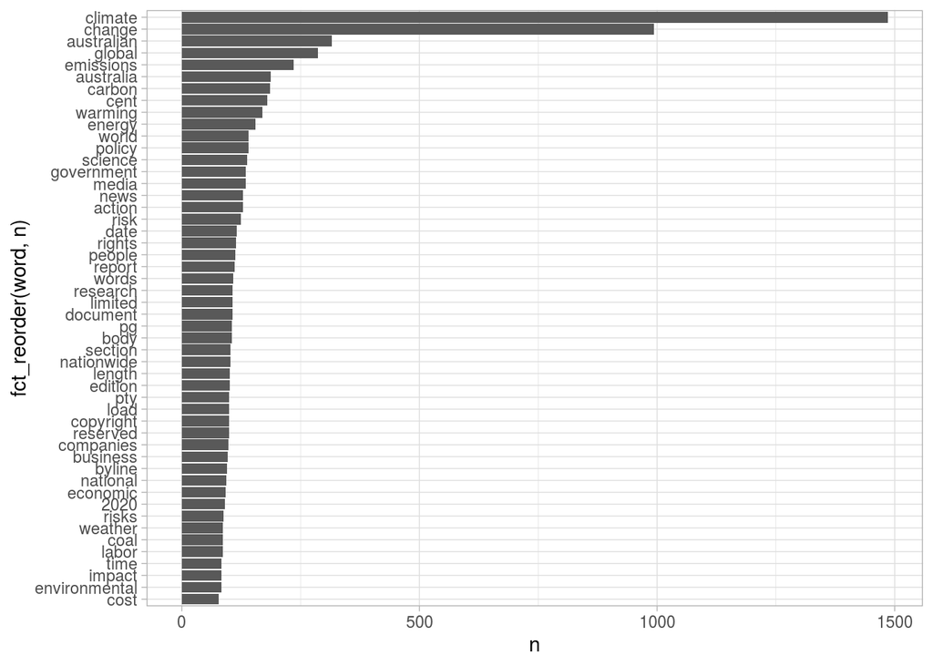

We can see in the plot that “climate” and “change” were yet again the most used words, as noted for the same reason as the previous publications. Following that, we see “australian”, “global”, and “emissions”, all with more or less 250 words. Other words along the graph seem to be both about environmental policy and business, so the sentiments regarding these will be interesting to see as we continue our analysis.

### The Guardian ggplot of Frequency of Words

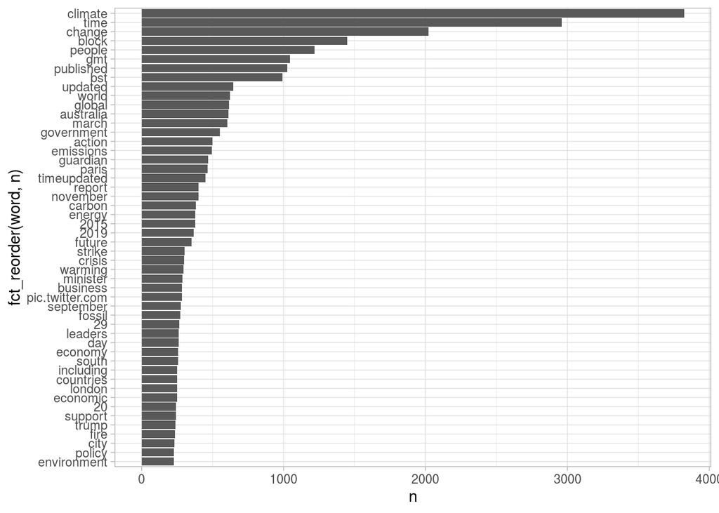

### The Global and Mail ggplot of Frequency of Words

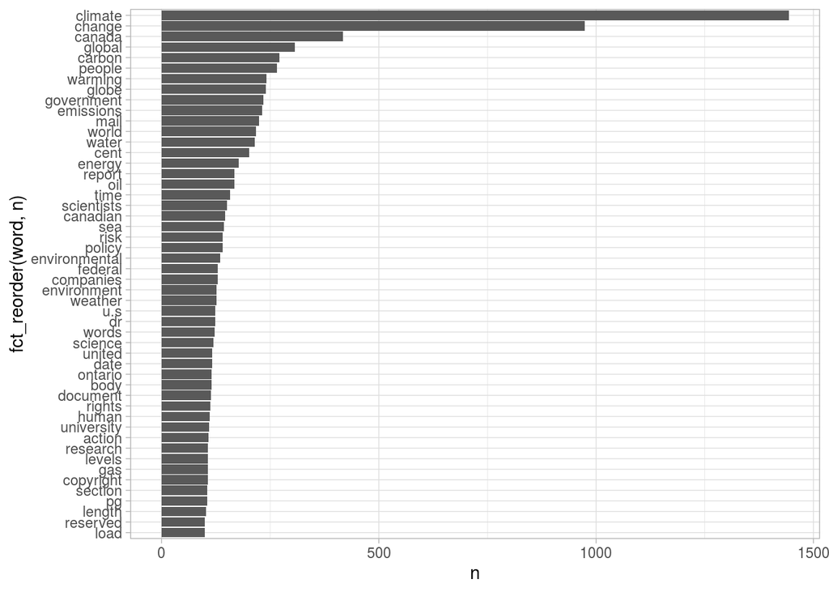

“Climate” and “change” were yet again the most used words for this publication, like the others. However, The Global and Mail had a few different words that occurred the most - “canada”, “global”, and “carbon”. As it is a Canadian publication, it makes sense that Canada was mentioned often. Many other scietific terms were mentioned most often - including: “carbon”, “warming”, “emissions”, “water”, and “energy”.

## Analyzing the Sentiment

Now that we have prepared the data for use, we can begin our sentiment analysis. For the purposes of our analysis, we will be using the afinn, bing, and nrc lexicon from the text data package. From here, we can perform an inner join on the data set and the three different lexicons to get varying information on the sentiments. The afinn lexicon provides a numerical representation of the sentiment, where the sign represents intuitively a positive or negative sentiment, and the magnitude represents the strength of the sentiment. Bing provides a binary classification: the word is either positive or negative. Lastly, nrc provides more specific sentiments that surround a word; this will likely be the most informative and where we can extract the most meaningful conclusions.

We can graphically and numerically analyze the sentiments looking at a distribution of the afinn sentiment results.

### Usa Today Sentiment Table

```
## # A tibble: 760 x 3
##    word          n value
##    <chr>     <int> <dbl>
##  1 united      204     1
##  2 natural     106     1
##  3 severe       59    -2
##  4 increase     55     1
##  5 increased    51     1
##  6 risk         45    -2
##  7 cut          44    -1
##  8 agreement    39     1
##  9 crisis       39    -3
## 10 disasters    39    -2
## # … with 750 more rows
```

The tabled list includes the words and their counts, as well as their sentiment values that will be put into a ggplot graph later. The most used words were “united”, “natural”, “severe”, “increase(d)”, and “risk”. These words represent negative and positive sentiment pretty evenly, however, as we move along the table, more negative sentiment is noted.

### NYT Sentiments Table

```
## # A tibble: 1,645 x 3
##    word        n value
##    <chr>   <int> <dbl>
##  1 united    632     1
##  2 care      366     2
##  3 war       330    -2
##  4 love      320     3
##  5 support   293     2
##  6 true      287     2
##  7 agree     281     1
##  8 bad       277    -3
##  9 pretty    255     1
## 10 stop      242    -1
## # … with 1,635 more rows
```

### Fox News Sentiment Table

```
## # A tibble: 1,064 x 3
##    word         n value
##    <chr>    <int> <dbl>
##  1 united     273     1
##  2 natural    199     1
##  3 fire       159    -2
##  4 risk       142    -2
##  5 matter     140     1
##  6 risks       86    -2
##  7 top         77     2
##  8 crisis      75    -3
##  9 increase    75     1
## 10 threat      70    -2
## # … with 1,054 more rows
```

The table shows sentiment values regarding words in articles from Fox News. There is clearly an imbalance towards negative sentiment, as the words with negative sentiment saw high negative values. Positive sentiment words in the table include “united”, “natural”, “matter”, “top”, and “increase”. Negative sentiment words in the table include “fire”, “risk(s)”, “crisis”, and “threat”.

### The Australian Sentiment Table

```
## # A tibble: 822 x 3
##    word            n value
##    <chr>       <int> <dbl>
##  1 risk          125    -2
##  2 limited       107    -1
##  3 risks          88    -2
##  4 natural        75     1
##  5 increase       71     1
##  6 increased      50     1
##  7 support        50     2
##  8 significant    47     1
##  9 fire           39    -2
## 10 challenge      38    -1
## # … with 812 more rows
```

The table created indicates a slight favoring of negative sentiment in The Australian regarding climate change. Each of the top three (“risk”, “limited, and”risks") registered negative sentiment - immediately indicating the tone of the publication.

### The Guardian Sentiment Table

```
## # A tibble: 1,155 x 3
##    word           n value
##    <chr>      <int> <dbl>
##  1 block       1448    -1
##  2 strike       304    -1
##  3 crisis       297    -3
##  4 support      241     2
##  5 fire         234    -2
##  6 growth       166     2
##  7 emergency    151    -2
##  8 risk         145    -2
##  9 agreement    140     1
## 10 protesters   138    -2
## # … with 1,145 more rows
```

The table shown indicates a major negative sentiment in The Guardian. Most importantly, the word “block” was used 1448 times with a negative sentiment. This could be in regards to climate change legislation that didn’t get written into law. Other words, like “strike”, “crisis”, “fire”, and "emergency added to this negative sentiment.

### The Global and Mail Sentiment Table

```
## # A tibble: 976 x 3
##    word          n value
##    <chr>     <int> <dbl>
##  1 risk        141    -2
##  2 united      117     1
##  3 risks        91    -2
##  4 natural      83     1
##  5 increase     68     1
##  6 growing      57     1
##  7 crisis       54    -3
##  8 threat       53    -2
##  9 support      51     2
## 10 increased    47     1
## # … with 966 more rows
```

The words in the table for The Global and Mail seem to be fairly equal in sentiment. “Risk” and “United” were terms used frequently with both positive and negative sentiments. In addition, as the list is examined, words like “natural”, “crisis”, “threat”, and “increased” show alternating sentiments for the publication.

## Graphing the Sentiments

We can graphically and numerically analyze the sentiments looking at a distribution of the afinn sentiment results.

### USA Sentiment ggplot

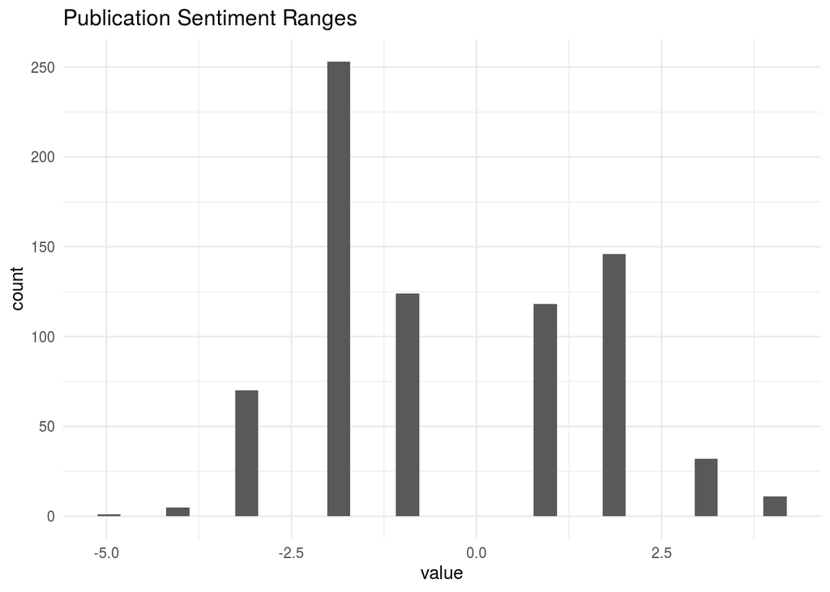

From the sentiment ranges graph, we can see that there is notably more negative sentiment regarding climate change. In order to more closely examine this sentiment, we created a word cloud to discover which words were showing up the most often.

### NYT Sentiment ggplot

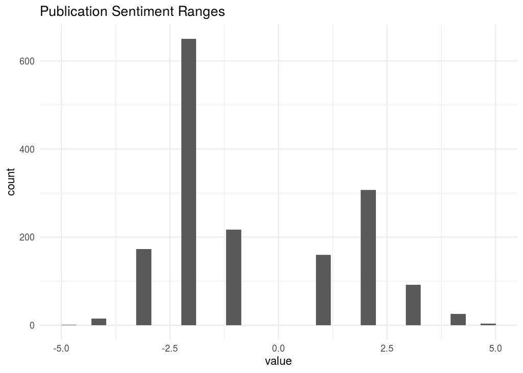

### Fox News Sentiment ggplot

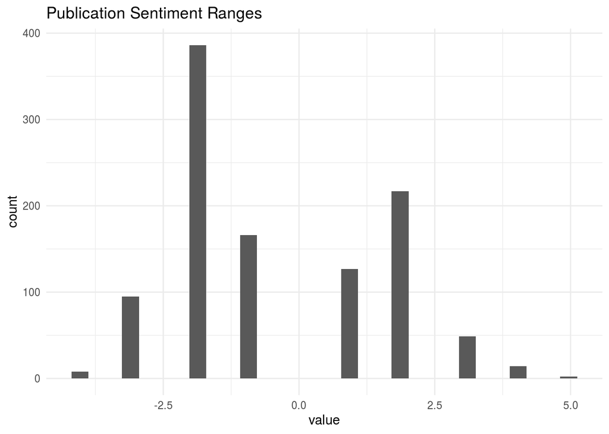

Once again, we can see in the sentiment graph that there is an uneven distribution between negative and positive sentiment. The negative sentiment is nearly double the value of positive sentiment, indicating that the tone of these climate change articles in Fox News isn’t hopeful.

### The Australian Sentiment ggplot

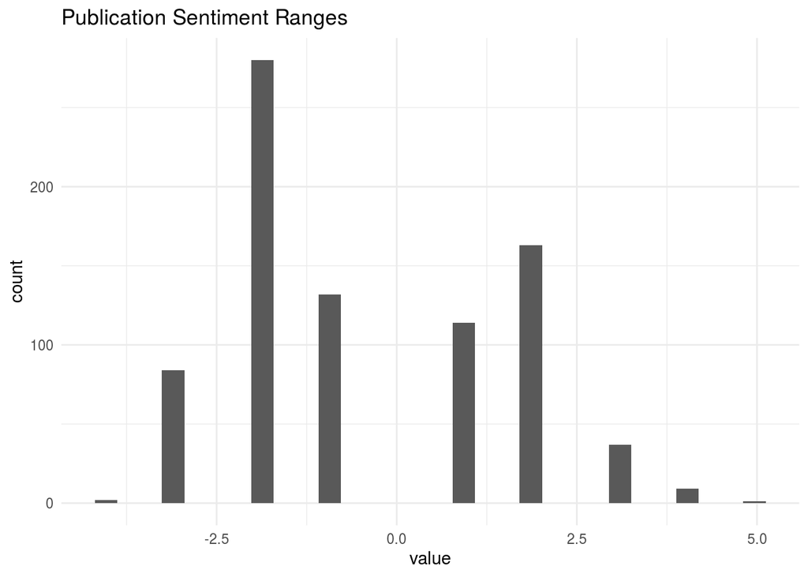

### The Guardian Sentiment ggplot

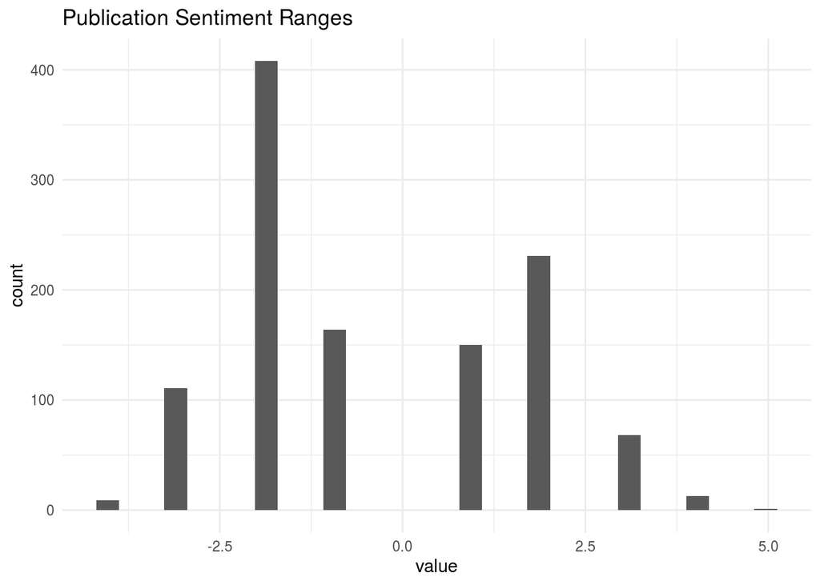

### The Global and Mail Sentiment ggplot

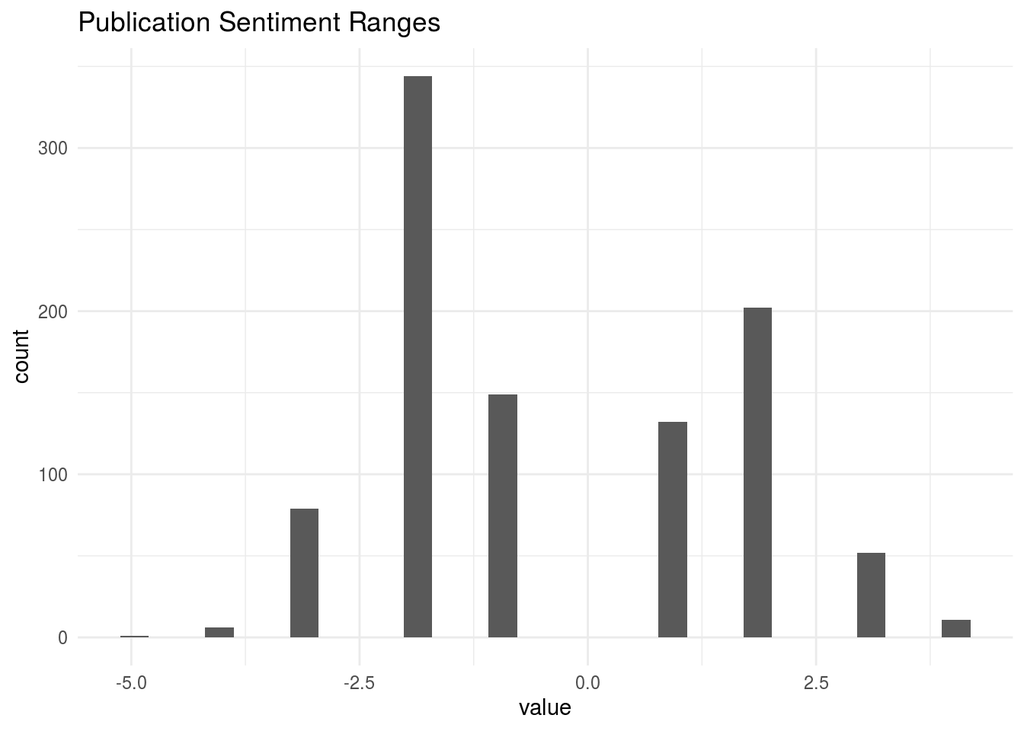

Upon further examination of The Global and Mail, negative sentiment towards climate change overwhelms the positive sentiment of climate change at nearly every level. This indicates a worrisome attitude towards climate change from Canada. Eh?

## Creating a Word Cloud

In order to analyze the words in our publication, we can create a wordcloud.

### USA today Sentiment wordcloud

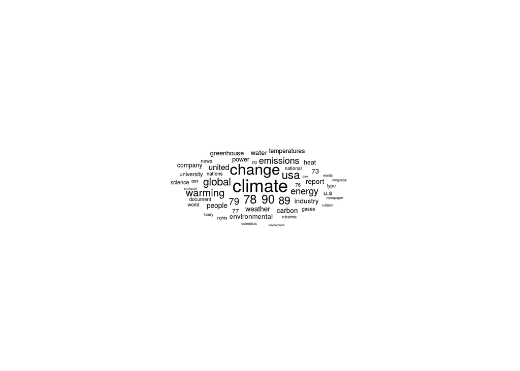

As seen in the wordcloud, “climate” and “change” were the most used words, and were very similar in size - as they are typically used together. Other words that were used often were “global” and “warming” (also typically used together and of similar size on the wordcloud), “energy”, “emissions”, “usa”, and a variety of different numbers.

### NYT Sentiment wordcloud

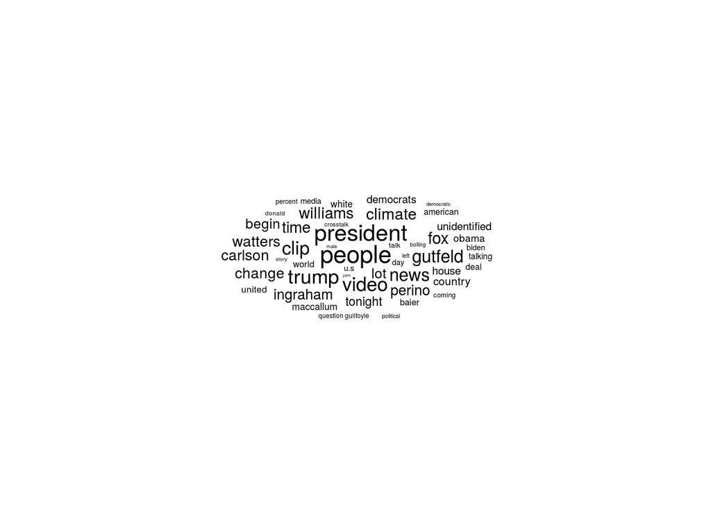

### Fox News Sentiment wordcloud

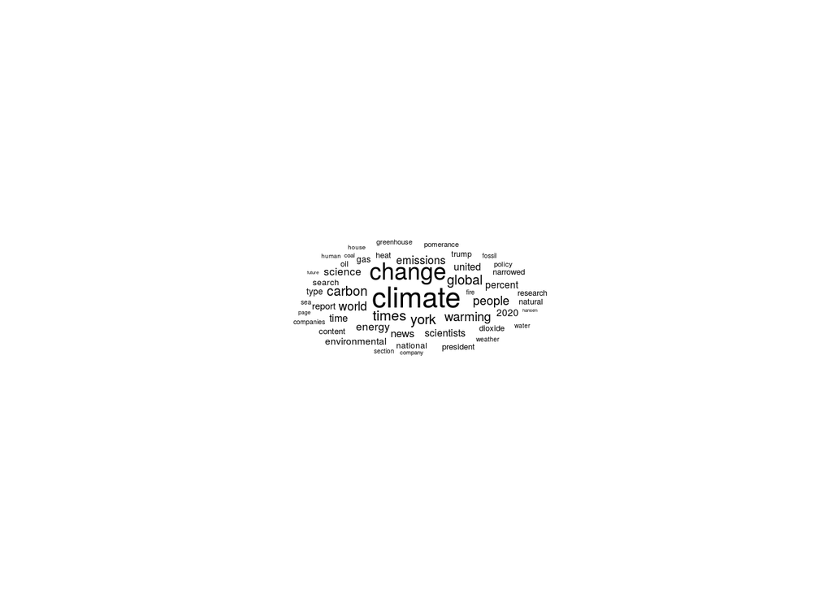

### The Australian Sentiment wordcloud

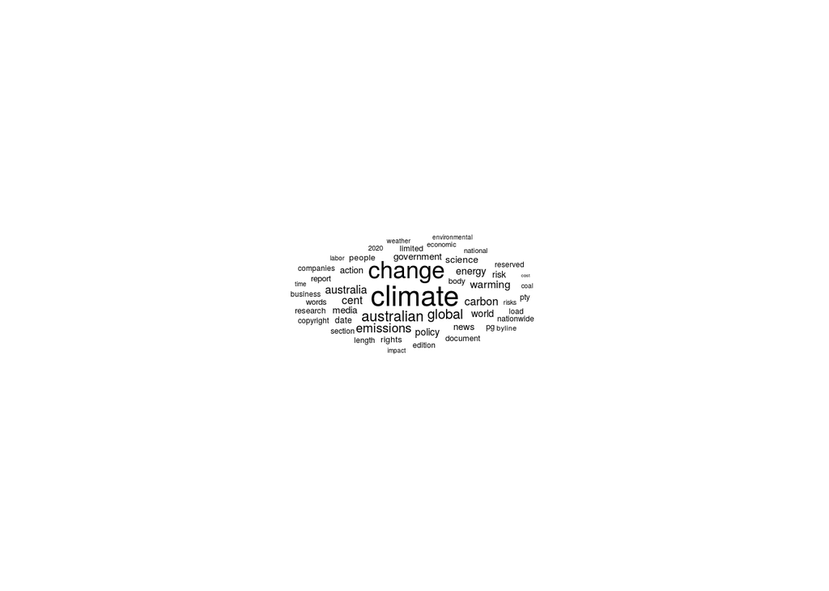

In the word cloud, “climate” and “change” clearly overshadow the other words, as expected. However, many words related to policy and legislation can be seen - such as “research”, “document”, “government” and “report”. This denotes that articles in The Australia may be more legality based when compared to US publications regarding politics and science.

### The Guardian Sentiment wordcloud

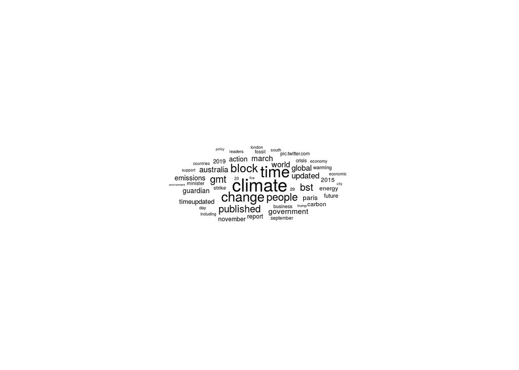

“climate” and “change” are yet again the most used words - which is as predicted. “time”, “people”, and “block” were also frequently used words. we can also see in the word cloud that locations and dates were also frequently seen - “paris”, “2015”, “november”, “australia”, and “march” to name a few. these could indicate important times or places in the fight to put an end to climate change.

### The Global and Mail Sentiment wordcloud

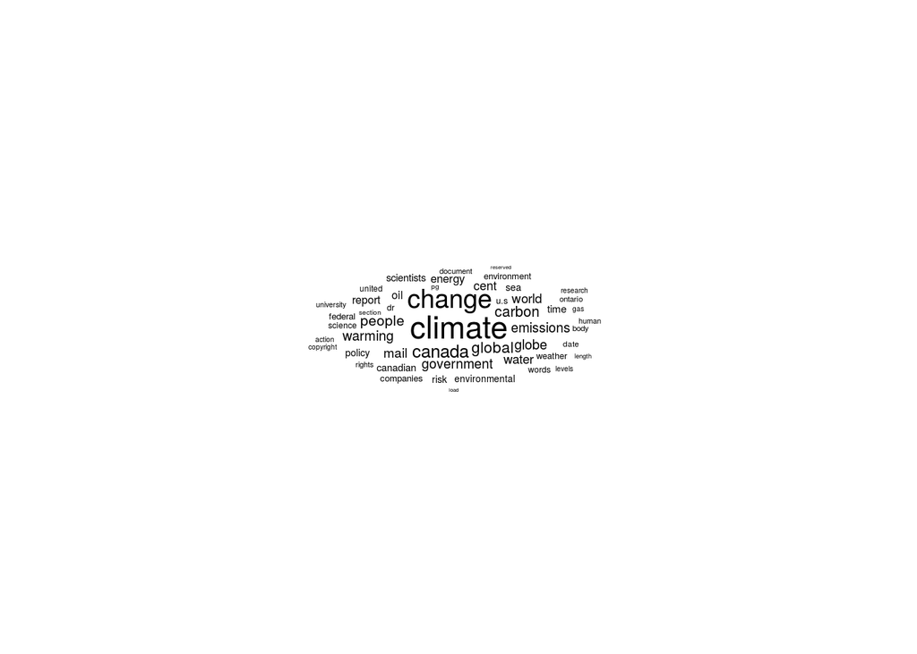

We can see, via the word cloud for The Global and Mail, that “climate” and “change” were mentioned a huge amount of times. Other notable terms - like “global”, “warming”, “carbon”, “energy”, “scientists”, and “water” - indicate a more scientific and factual approach to climate change by the publication.

## Final Thoughts

To give our final recommendations, it is imperative to keep our target audience in mind. Although international sources, especially in comparable developing countries, are advantageous to analyze for a holistic picture of the sentiments surrounding climate change, more weight should be placed on the American outlets. This is because our focus is on American politics. However, this should not, and does not discredit the information we can derive from international news sources; especially more liberal countries, analyzing the sentiments surrounding climate change in their respect country, could be advantageous to see what strategies and investments have worked to help push their agenda. Furthermore, for the time being, we will focus on our American news outlets. Intuitively, it makes sense that no time nor resources who are already in support of environmental policies, which leads us with those on the fringes and those who are actively opposed. Exogenous of our findings, we believe that the easier and more advantageous group to capture is the fringe group. Radical groups that dismiss the very existence of climate change are not likely to easily change their mind, and likely would require a lot of time and resources to achieve any return on investment. However, the people on the fringe hold ample opportunity. We found through our sentiment analysis, that many of these news sources tended to lean in a negative sentiment, but only slightly. Often times the discussion of climate change is brought up, but not really in the context of tangible policy change. This should be a huge indicator of opportunity: they are open to the idea of change, but may not know exactly what that looks like. Investing in pushing environmental policy out to these news outlets to inform readers, who are also likely to be moderate as well, goes beyond just being knowledgeable about what climate change is. It offers an opportunity to see a tangible and concrete solution to a problem that they see presented to them in the media.